# Science Mapping Analysis of Research using Sysrev

Sarah Young

September 2, 2025

# Bibliographic Collection

**Data source**: Clarivate Analytics Web of Science (http://apps.webofknowledge.com)

**Data format**: bibtex

**Query**: DO=(“10.1002/2688-8319.12304” OR “10.1007/978-3-031-50531-7_2” OR “10.1007/s00296-023-05275-9” OR “10.1007/s10584-025-03892-w” OR “10.1007/s10661-020-08781-6” OR “10.1007/s11160-022-09751-6” OR “10.1007/s11160-023-09780-9” OR “10.1007/s11625-023-01439-5” OR “10.1007/s11701-024-02060-z” OR “10.1007/s12144-023-04527-y” OR “10.1007/s43388-025-00224-5” OR “10.1016/j.actatropica.2022.106509” OR “10.1016/j.biopha.2024.116530” OR “10.1016/j.biopha.2025.118459” OR “10.1016/j.bjoms.2024.09.001” OR “10.1016/j.chemosphere.2023.139572” OR “10.1016/j.cosust.2022.101159” OR “10.1016/j.ekir.2020.10.023” OR “10.1016/j.envpol.2024.124109” OR “10.1016/j.fishres.2024.106947” OR “10.1016/j.gfs.2024.100744” OR “10.1016/j.gfs.2024.100775” OR “10.1016/j.jafr.2024.101095” OR “10.1016/j.jbi.2023.104465” OR “10.1016/j.namjnl.2025.100036” OR “10.1016/j.neuro.2023.11.001” OR “10.1016/j.rvsc.2023.105102” OR “10.1016/j.scitotenv.2022.153043” OR “10.1016/j.tox.2024.153814” OR “10.1016/S2542-5196(21)00149-2” OR “10.1016/S2542-5196(24)00273-0” OR “10.1017/S0950268823001309” OR “10.1038/s41558-021-01170-y” OR “10.1038/s41558-023-01824-z” OR “10.1038/s41597-023-02633-x” OR “10.1038/s41598-021-85708-2” OR “10.1080/01930826.2021.1984139” OR “10.1080/10503307.2025.2457389” OR “10.1080/18387357.2023.2235030” OR “10.1093/aje/kwae410” OR “10.1093/jac/dkad350” OR “10.1097/ANA.0000000000000799” OR “10.1097/NPT.0000000000000456” OR “10.1101/2024.05.28.595900” OR “10.1101/2025.03.16.25324060” OR “10.1109/ICNAS53565.2021.9628931” OR “10.1111/bjet.13277” OR “10.1111/csp2.12687” OR “10.1111/csp2.70026” OR “10.1111/epi.17352” OR “10.1111/gcb.17305” OR “10.1111/icad.12493” OR “10.1111/medu.14779” OR “10.1136/bmjopen-2021-058069” OR “10.1145/3474656” OR “10.1145/3534617” OR “10.1145/3546726” OR “10.1145/3640792.3675730” OR “10.1155/tbed/9880670” OR “10.1186/s12906-025-04825-x” OR “10.1186/s12911-025-02884-1” OR “10.1186/s13750-020-00214-8” OR “10.1186/s13750-021-00217-z” OR “10.1186/s13750-021-00234-y” OR “10.1186/s13750-022-00261-3” OR “10.1186/s13750-022-00281-z” OR “10.1186/s41043-024-00656-7” OR “10.1186/s42269-023-01008-x” OR “10.1186/s42269-023-01145-3” OR “10.1186/s43088-023-00431-3” OR “10.1210/endocr/bqad081” OR “10.1249/MSS.0000000000003187” OR “10.1289/EHP15086” OR “10.1289/EHP15394” OR “10.13102/sitientibus.v1i65.11200” OR “10.1371/journal.pone.0253587” OR “10.1371/journal.pone.0265514” OR “10.1371/journal.pone.0272839” OR “10.1371/journal.pone.0284099” OR “10.1371/journal.pone.0292891” OR “10.1371/journal.pone.0300930” OR “10.1371/journal.pone.0304505” OR “10.1371/journal.pone.0326521” OR “10.14569/IJACSA.2020.0110933” OR “10.14573/altex.2403211” OR “10.14573/altex.2412241” OR “10.17605/OSF.IO/8WFYH” OR “10.17879/freeneuropathology-2024-5373” OR “10.21203/rs.3.pex-2324/v1” OR “10.2139/ssrn.5228189” OR “10.21863/jcar/2024.13.4.001” OR “10.24059/olj.v28i2.3954” OR “10.2514/6.2024-1130” OR “10.31157/an.v27i2.331” OR “10.31157/an.v28i1.354” OR “10.31157/an.v28i2.356” OR “10.31157/an.v28i4.363” OR “10.31157/an.v29i1.441” OR “10.31219/osf.io/4e9yg” OR “10.32942/X2R929” OR “10.3389/fcimb.2019.00223” OR “10.3389/fclim.2022.1072231” OR “10.3389/fnut.2021.759885” OR “10.3389/frai.2022.984836” OR “10.3389/ftox.2025.1619651” OR “10.3389/fvets.2023.1231711” OR “10.3390/agronomy11040619” OR “10.3390/ai6010010” OR “10.3390/biology11020209” OR “10.3390/cli12090141” OR “10.3390/educsci14020200” OR “10.3390/healthcare12222309” OR “10.3390/ijerph17144942” OR “10.3390/ijerph21040392” OR “10.3390/jcm13206133” OR “10.3390/ph17030272” OR “10.3390/s21217259” OR “10.3390/su15064996” OR “10.3390/su16114353” OR “10.3390/vetsci9040186” OR “10.35376/10324/62581” OR “10.3897/rio.7.e70486” OR “10.58209/ijbc.14.2.85” OR “10.5937/arhfarm74-49552”)

**Timespan**: All years

**Document Type**: Articles, letters, review and proceedings papers

**Query data**: Sept 2, 2025

# Descriptive Analysis

Descriptive analysis provides some snapshots about the annual research development, the top “k” productive authors, papers, countries and most relevant keywords.

## Main findings about the collection

```
##
##
## MAIN INFORMATION ABOUT DATA
##
##  Timespan                              2019 : 2025
##  Sources (Journals, Books, etc)        74
##  Documents                             92
##  Annual Growth Rate %                  51.31
##  Document Average Age                  1.96
##  Average citations per doc             16.76
##  Average citations per year per doc    4.389
##  References                            7828
##
## DOCUMENT TYPES
##  article                    33
##  article; data paper        1
##  article; early access      1
##  news item                  1
##  proceedings paper          1
##  review                     55
##
## DOCUMENT CONTENTS
##  Keywords Plus (ID)                    532
##  Author's Keywords (DE)                372
##
## AUTHORS
##  Authors                               854
##  Author Appearances                    965
##  Authors of single-authored docs       0
##
## AUTHORS COLLABORATION
##  Single-authored docs                  0
##  Documents per Author                  0.108
##  Co-Authors per Doc                    10.5
##  International co-authorships %        48.91
##
##
## Annual Scientific Production
##
##  Year    Articles
```

[output cut: 89 more lines]

```
##
##
## Most Relevant Keywords
##
##    Author Keywords (DE)      Articles Keywords-Plus (ID)     Articles
## 1    SYSTEMATIC REVIEW              7     BIODIVERSITY              6
## 2    EVIDENCE SYNTHESIS             6     RISK                      6
## 3    CLIMATE CHANGE                 4     HEALTH                    5
## 4    ADVERSE OUTCOME PATHWAY        3     DETERMINANTS              4
## 5    ARTIFICIAL INTELLIGENCE        3     IMPACT                    4
## 6    COVID-19                       3     ADAPTATION                3
## 7    META-ANALYSIS                  3     ECOSYSTEM SERVICES        3
## 8    ASSESSMENT                     2     FOOD                      3
## 9    BIODIVERSITY FRAMEWORK         2     FUTURE                    3
## 10   ENVIRONMENTAL                  2     GROWTH                    3
```

[figure not shown]

[figure not shown]

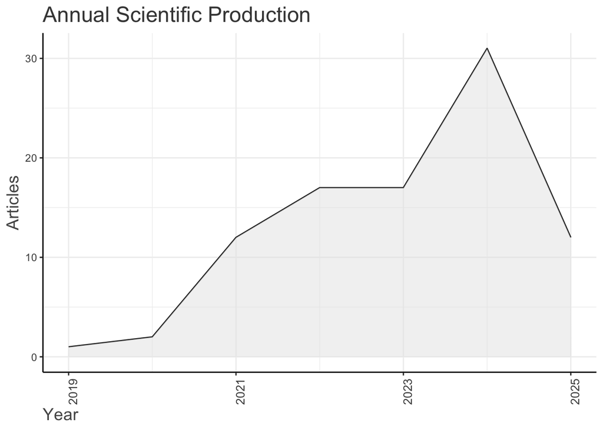

[figure not shown]

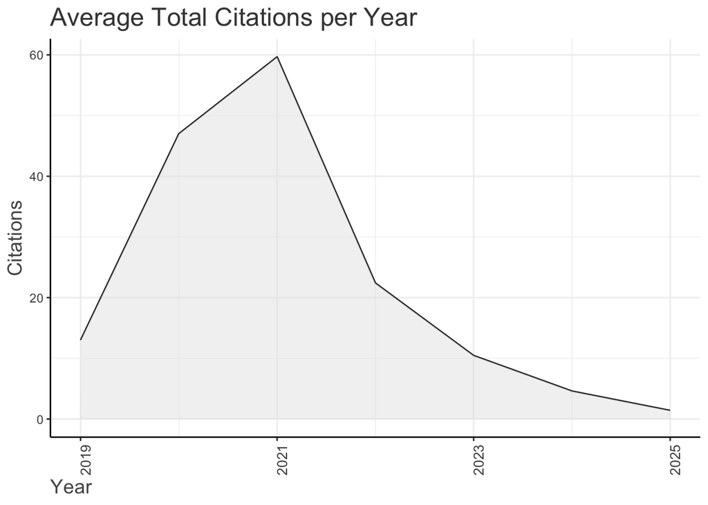

## Top journals

| SO | count |
| --- | --- |
| PLOS ONE | 8 |
| ENVIRONMENTAL EVIDENCE | 5 |
| ALTEX-ALTERNATIVES TO ANIMAL EXPERIMENTATION | 2 |
| CONSERVATION SCIENCE AND PRACTICE | 2 |
| GLOBAL FOOD SECURITY-AGRICULTURE POLICY ECONOMICS AND ENVIRONMENT | 2 |
| LANCET PLANETARY HEALTH | 2 |
| NATURE CLIMATE CHANGE | 2 |
| REVIEWS IN FISH BIOLOGY AND FISHERIES | 2 |
| SUSTAINABILITY | 2 |
| ACTA TROPICA | 1 |

## Top institutions

| affiliations | n |
| --- | --- |
| UTRECHT UNIVERSITY | 9 |
| UNIVERSITY OF SYDNEY | 8 |
| UNIVERSITY OF HAMBURG | 7 |
| UNIVERSITY OF CALIFORNIA SYSTEM | 6 |
| UNIVERSITY OF LIVERPOOL | 6 |
| UNIVERSITY OF LONDON | 6 |
| UNIVERSITY OF MUNICH | 6 |
| VRIJE UNIVERSITEIT BRUSSEL | 6 |
| CIBER - CENTRO DE INVESTIGACION BIOMEDICA EN RED | 5 |
| CIBEREHD | 5 |
| NORWEGIAN INSTITUTE OF PUBLIC HEALTH (NIPH) | 5 |
| UNIVERSITY OF VALENCIA | 5 |
| CENTRE NATIONAL DE LA RECHERCHE SCIENTIFIQUE (CNRS) | 4 |
| CGIAR | 4 |
| CORNELL UNIVERSITY | 4 |
| INTERNATIONAL LIVESTOCK RESEARCH INSTITUTE (ILRI) | 4 |
| JOHNS HOPKINS BLOOMBERG SCHOOL OF PUBLIC HEALTH | 4 |
| JOHNS HOPKINS UNIVERSITY | 4 |
| NETHERLANDS NATIONAL INSTITUTE FOR PUBLIC HEALTH & THE ENVIRONMENT | 4 |
| PENNSYLVANIA COMMONWEALTH SYSTEM OF HIGHER EDUCATION (PCSHE) | 4 |

## Top funders

Top 20 Funders

| FU | n |
| --- | --- |
| EUROPEAN UNION | 5 |
| EUROPEAN UNION [963845] | 3 |
| BILL AND MELINDA GATES FOUNDATION [INV-005366] FUNDING SOURCE: BILL AND MELINDA GATES FOUNDATION | 2 |
| EUROPEAN COMMISSION | 2 |
| GERMAN FEDERAL MINISTRY OF EDUCATION AND RESEARCH (BMBF) [01LN1710A1] | 2 |
| NATIONAL INSTITUTE OF ENVIRONMENTAL HEALTH SCIENCES | 2 |
| SPANISH MINISTRY OF SCIENCE AND INNOVATION | 2 |
| 2017-2018 BELMONT FORUM AND BIODIVERSA JOINT CALL FOR RESEARCH PROPOSALS, UNDER THE BIODIVSCEN ERA-NET COFUND PROGRAMME | 1 |
| ACCELERATING IMPACTS OF CGIAR CLIMATE RESEARCH FOR AFRICA (AICCRA) PROJECT - INTERNATIONAL DEVELOPMENT ASSOCIATION (IDA) OF THE WORLD BANK | 1 |
| AGENCE FRANCAISE DE DEVELOPPEMENT | 1 |
| AGENCE NATIONALE DE LA RECHERCHE (ANR) [ANR-18-EBI4-0003] FUNDING SOURCE: AGENCE NATIONALE DE LA RECHERCHE (ANR) | 1 |
| AGENCE NATIONALE POUR LA RECHERCHE (FRENCH NATIONAL RESEARCH AGENCY) [ANR-10-LABX-14-01, ANR-15-CE03-0003] | 1 |
| AGRICULTURAL EXPERIMENT STATION HATCH PROJECTS [CA-R-A-6689-H, CA-D-LAW-2352-H] | 1 |
| AGRIFUTURES AUSTRALIA [PRJ-011719] | 1 |
| ALTERNATIVES RESEARCH AND DEVELOPMENT FOUNDATION | 1 |
| ANR [101059823, B-USEFUL] | 1 |
| ANR [ANR-18-EBI4-0003-01] | 1 |
| ASPIS PROJECT CLUSTER | 1 |
| AUSTRALIAN CENTRE FOR INTERNATIONAL AGRICULTURAL RESEARCH (ACIAR) | 1 |
| AUSTRALIAN DEPARTMENT OF EDUCATION, SKILLS AND EMPLOYMENT, ENABLING GROWTH AND INNOVATION PROGRAM | 1 |

# The Intellectual Structure of the field

Citation analysis is one of the main classic techniques in bibliometrics. It shows the structure of a specific field through the linkages between nodes (e.g. authors, papers, journal), while the edges can be differently interpreted depending on the network type.

The following shows a co-citation network that uses cited journals as the unit of analysis.

## Journal (Source) co-citation analysis

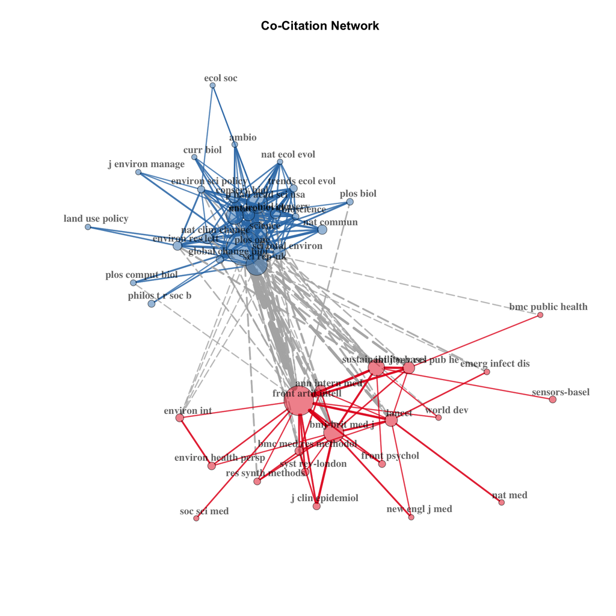

# The conceptual structure - Co-Word Analysis

Co-word analysis draws clusters of keywords. They are considered as themes, whose density and centrality can be used in classifying themes and mapping in a two-dimensional diagram.

## Co-word Analysis through Keyword co-occurrences

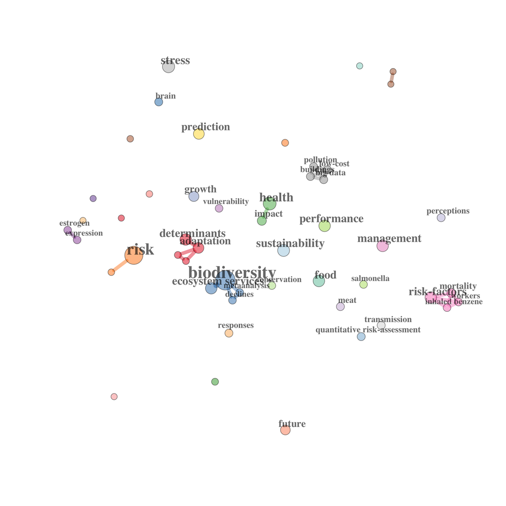

## Thematic Map

Thematic map is a very intuitive plot and we can analyze themes according to the quadrant in which they are placed: (1) upper-right quadrant: motor-themes (developed and central topics); (2) lower-right quadrant: basic themes (frequently occurring); (3) lower-left quadrant: emerging or disappearing themes; (4) upper-left quadrant: very specialized/niche themes.

[figure not shown]

# Table of public projects

| Citation | Project Links |
| --- | --- |
| Fayad, Claire et al. (2024). A systematic review and meta-analysis of factors related to first line drugs refractoriness in patients with juvenile myoclonic epilepsy (JME). PLOS ONE, 19(4), e0300930. … | https://www.sysrev.com/u/8164/p/119967 |
| Maxwell, Tania L. et al. (2023). Global dataset of soil organic carbon in tidal marshes. Scientific Data, 10(1), 797. https://doi.org/10.1038/s41597-023-02633-x | https://www.sysrev.com/u/6789/p/117521 |
| Stampf, Annika et al. (2022). Towards Implicit Interaction in Highly Automated Vehicles - A Systematic Literature Review. Proc. ACM Hum.-Comput. Interact., 6(MHCI), 191:1. https://doi.org/10.1145/3546… | https://www.sysrev.com/u/5332/p/79138 |
| Williamson, Michael J. et al. (2023). The drivers of anguillid eel movement in lentic water bodies: a systematic map. Reviews in Fish Biology and Fisheries, 33(1), 147. https://doi.org/10.1007/s11160-… | https://www.sysrev.com/u/6827/p/116118 |
| HaimerlⰠ, Mathias et al. (NA). Influence of Automated Vehicle Signaling on Mental Workload in People with Intellectual Disabilities. NA, NA. | https://www.sysrev.com/u/9853/p/121743 |
| Meerman, Julia J. et al. (2025). Including genetic susceptibility towards Parkinson’s disease in NAM-based hazard and risk assessment of pesticides: a semi-systematic review. NAM Journal, 1, 100036. h… | https://www.sysrev.com/o/353/p/125011 |
| Martin, Philip et al. (2025). A systematic map of forest disturbance impacts on soil and litter fauna: knowledge gaps and a roadmap for future research. NA, NA. | https://www.sysrev.com/u/973/p/98916 |
| Drey, Tobias et al. (2021). To Be or Not to Be Stuck, or Is It a Continuum?: A Systematic Literature Review on the Concept of Being Stuck in Games. Proceedings of the ACM on Human-Computer Interaction… | https://www.sysrev.com/u/2468/p/34483 |
| Agarwal, Deevyankar et al. (2021). Transfer Learning for Alzheimer’s Disease through Neuroimaging Biomarkers: A Systematic Review. Sensors, 21(21), 7259. https://doi.org/10.3390/s21217259 | https://www.sysrev.com/u/1468/p/36874 |
| McKenzie, Andrew T. et al. (NA). Fluid preservation in brain banking: a review. Free Neuropathology, 5, 10. https://doi.org/10.17879/freeneuropathology-2024-5373 | https://www.sysrev.com/u/5668/p/123382, https://www.sysrev.com/u/5668/p/123457 |
| Agarwal, Deevyankar (2023). DEEP-AD: The deep learning model for diagnostic classification and prognostic prediction of alzheimer’s disease. NA, NA. https://doi.org/10.35376/10324 | https://www.sysrev.com/u/2642/p/118998 |
| Le Billan, Florian et al. (2023). Regulation of Alternative Splicing by Steroid Hormones. Endocrinology, 164(7), bqad081. https://doi.org/10.1210/endocr | https://www.sysrev.com/u/5078/p/72871 |
| Jansen, Pascal et al. (2022). A Design Space for Human Sensor and Actuator Focused In-Vehicle Interaction Based on a Systematic Literature Review. Proceedings of the ACM on Interactive, Mobile, Wearab… | https://sysrev.com/u/5286/p/77887, https://sysrev.com/u/5286/p/78991 |
| Caretta, Martina Angela et al. (2021). 28 PUBLICATIONS 199 CITATIONS SEE PROFILE. Technical Report, NA. | https://www.sysrev.com/u/1502/p/28357 |
| Artsitas, Sotirios et al. (2023). Hypoglycemia rates and glycemic hormonal response after laparoscopic Roux-en-Y gastric bypass versus sleeve gastrectomy: a meta-analysis of comparative studies. Bulle… | https://www.sysrev.com/u/8078/p/123461 |
| Paller, Channing et al. (2020). Vitamin C and Cancer: An Overview of Recent Clinical Trials. Cancer and Vitamin C, NA. | https://sysrev.com/p/6737, https://sysrev.com/p/7162, https://sysrev.com/p/6963 |
| Artsitas, Sotirios et al. (2023). Robotic versus open partial nephrectomy in the context of mild severity complications: a meta-analysis of comparative studies supplemented by meta-regression. Bulleti… | https://www.sysrev.com/u/8078/p/119881 |
| Artsitas, Sotirios et al. (2024). Comparing robotic and open partial nephrectomy under the prism of surgical precision: a meta-analysis of the average blood loss rate as a novel variable. Journal of R… | https://www.sysrev.com/u/8078/p/119881 |
| Yatcilla, Jane Kinkus et al. (2021). Library Responses During the Early Days of the Pandemic: A Bibliometric Study of the 2020 LIS Literature. Journal of Library Administration, 61(8), 964. https://do… | https://www.sysrev.com/u/1968/p/55730 |
| Suponin, Andrei et al. (2024). Therapeutic Vaccines for Follicular Lymphoma: A Systematic Review. Pharmaceuticals, 17(3), 272. https://doi.org/10.3390/ph17030272 | https://www.sysrev.com/u/11470/p/123185/article/93581419 |
| Artsitas, Sotirios et al. (2023). A prototype variable corresponding to the proportion of ischemia for the comparison between robotic and open partial nephrectomy: a meta-analysis accompanied by sensi… | https://www.sysrev.com/u/8078/p/119881 |
| Selvaag, Sofie Kjendlie et al. (2022). On-site communication measures as a tool in outdoor recreation management: a systematic map protocol. Environmental Evidence, 11(1), 7. https://doi.org/10.1186/s… | https://www.sysrev.com/u/4293/p/63330 |
| Saunders, Manu E. et al. (2021). Limited understanding of bushfire impacts on Australian invertebrates. Insect Conservation and Diversity, 14(3), 285. https://doi.org/10.1111/icad.12493 | https://www.sysrev.com/u/992/p/24557 |
| Krishna, Shagun et al. (2022). High-Throughput Chemical Screening and Structure-Based Models to Predict hERG Inhibition. Biology, 11(2), 209. https://doi.org/10.3390/biology11020209 | https://www.sysrev.com/u/2376/p/35538 |
| Young, Sarah et al. (2025). A proposed workflow for semi-automating citation searching and screening: An example from a rapid review on digital applications for child online safety. NA, NA. https://do… | https://www.sysrev.com/o/1605/p/215266 |
| Artsitas, Sotirios et al. (2024). Comparative investigation of therapeutic efficacy in tumor resection between robotic and open partial nephrectomy: A meta-analysis supplemented by time-series and qua… | https://www.sysrev.com/u/8078/p/119881 |
| Martin, Philip A. et al. (2024). Meta-analysis reveals that the effects of precipitation change on soil and litter fauna in forests depend on body size. Global Change Biology, 30(5), e17305. https://d… | https://www.sysrev.com/u/973/p/98916 |
| Grames, Eliza M. et al. (2022). A framework and case study to systematically identify long-term insect abundance and diversity datasets. Conservation Science and Practice, 4(6), e12687. https://doi.or… | https://www.sysrev.com/o/78/p/16612 |
| Ehrlich, Daniel et al. (2024). Data-driven derivation of an adverse outcome pathway linking vascular endothelial growth factor receptor (VEGFR), endocrine disruption, and atherosclerosis. ALTEX - Alte… | https://www.sysrev.com/u/7746/p/119585 |
| Boyne, Pierce et al. (2024). Moderate to Vigorous Intensity Locomotor Training After Stroke: A Systematic Review and Meta-analysis of Mean Effects and Response Variability. Journal of Neurologic Physi… | https://www.sysrev.com/u/5631/p/93708, https://sysrev.com/u/5631/p/103118 |
| Ebel, Patrick et al. (2024). Changing Lanes Toward Open Science: Openness and Transparency in Automotive User Research. AutomotiveUI ’24: 16th International Conference on Automotive User Interfaces an… | https://www.sysrev.com/u/13220/p/124817, https://www.sysrev.com/u/13220/p/124810 |